# Homework 7 and 8

Kenna Rewcastle

3/21/2018

## Creating Fake Data Sets to Explore Hypotheses

The purpose of this exercise is to statistically explore an experimental design using simulated data before implenting the design. We will simulate data that would be expected if a specific hypothesis were true.

The response variable in this context is the $\delta$ <sup>13</sup>C signal in the phospholipid components of microbial cell membranes. Background, naturally occurring $\delta$ <sup>13</sup>C values for soil microbes is approximately -25 ‰, and values closer to 0 ‰ $\delta$ <sup>13</sup>C can be expected when microbes are actively breaking down and assimilating labeled substrates to the greatest extent. For each of six treatment groups (2 substrate types x 3 rhizosphere manipulation core types) there are 12 replicates.

#### Set up a data frame for data simulation.

```r
ID<-seq(from=1,to=72) # creates a unique ID for each sample
core<-rep(1:3,each=12,times=2) # string of core treatment IDs
label<-rep(c("L","S"),each=36) # string of substrate type IDs
```

#### Simulate $\delta$<sup>13</sup>C values (response variable) for each treatment group according to a normal distribution.

“L” denotes that mesocosms were labeled with a <sup>13</sup>C leaf substrate, and “S” denotes that a <sup>13</sup>C starch substrate was added. Cores labeled “1” were covered with a very fine mesh that excluded both roots and mycorrhizae from the mesocosms (-R-M), “2” cores were covered with a wider mesh that allowed mycorrhizal ingrowth but exluded roots from the mesoscms (-R+M), and “3” cores were covered with the largest diameter mesh that allowed both roots and mycorrhizae to access the mesocosms (+R+M).

```r
# Leaf labeled cores with effect of rhizosphere manipulation
L1<-rnorm(12,mean=-0,sd=10) # highest assimilation (no sugars from roots to eat, microbes are resorting to complex leaf material)
L2<-rnorm(12,mean=-10,sd=10) # moderate assimilation
L3<-rnorm(12,mean=-20,sd=10) # lowest assimilation of added substrate, mean is close to background levels
L<-c(L1,L2,L3) # All leaf data in one vector

# Strach labeled cores, rhizosphere manipulation does not affect microbial assimilation of substrate
S<-rnorm(36,mean=-15,sd=10)

# All assimilation values (leaf and starch) in one vector
leaf_starch<-c(L,S)
```

Collect simulated data and treatment IDs into one data frame.

```r
data<-data.frame(ID=ID,Rhizosphere_Manipulation=as.factor(core),Labeled_Substrate=label,Assimilation_13C=leaf_starch)

head(data)
```

```
##   ID Rhizosphere_Manipulation Labeled_Substrate Assimilation_13C
## 1  1                        1                 L        -8.719139
## 2  2                        1                 L       -12.730467
## 3  3                        1                 L        18.364648
## 4  4                        1                 L        -1.428691
## 5  5                        1                 L       -13.732890
## 6  6                        1                 L        20.988805
```

#### Analyzing simulated data and graphing results.

Write a simple ANOVA function to analyze the differences between microbial assimilation of the labeled substrate between rhizosphere manipulation treatments and substrate type (i.e. differing substrate complexity).

```r
#########################################################################################################
# FUNCTION: myANOVA
# Returns anova output that shows differences in microbial assimilation of 13C between treatments and substrate types.
# input: data = 4-column data frame (ID, rhizosphere manipulation treatment, substrate type, assimilation)
# output: ANOVA output table
#--------------------------------------------------------------------------------------------------------
library(dplyr)
myANOVA<-function(data=NULL) {
  if (is.null(data)) {
    data<-data.frame(ID=seq(from=1,to=72),
                     Rhizosphere_Manipulation=rep(1:3,each=12,times=2),
                     Labeled_Substrate=rep(c("L","S"),each=36),
                     Assimilation_13C=rnorm(72,mean=-15,sd=10))
  }

  leafData<-filter(data,Labeled_Substrate=="L")
  starchData<-filter(data,Labeled_Substrate=="S")

  starchMod<-lm(starchData$Assimilation_13C~starchData$Rhizosphere_Manipulation)
  starchResults<-anova(starchMod)
  print("STARCH SUBSTRATE RESULTS")
  print(starchResults)

  leafMod<-lm(leafData$Assimilation_13C~leafData$Rhizosphere_Manipulation)
  leafResults<-anova(leafMod)
  print("LEAF SUBSTRATE RESULTS")
  print(leafResults)
}
#--------------------------------------------------------------------------------------------------------

myANOVA() # Function works correctly, computes ANOVA on default dataset.
```

```
## [1] "STARCH SUBSTRATE RESULTS"
## Analysis of Variance Table
##
## Response: starchData$Assimilation_13C
##                                     Df  Sum Sq Mean Sq F value Pr(>F)
## starchData$Rhizosphere_Manipulation  1   39.49  39.490  0.4346 0.5142
## Residuals                           34 3089.69  90.873
## [1] "LEAF SUBSTRATE RESULTS"
## Analysis of Variance Table
##
## Response: leafData$Assimilation_13C
##                                   Df  Sum Sq Mean Sq F value Pr(>F)
## leafData$Rhizosphere_Manipulation  1   77.85  77.846  0.9568 0.3349
## Residuals                         34 2766.18  81.358
```

```r
myANOVA(data=data) # Function works correctly on simulated data.
```

```
## [1] "STARCH SUBSTRATE RESULTS"
## Analysis of Variance Table
##
## Response: starchData$Assimilation_13C
##                                     Df Sum Sq Mean Sq F value Pr(>F)
## starchData$Rhizosphere_Manipulation  2   11.1    5.56  0.0303 0.9702
## Residuals                           33 6051.3  183.37
## [1] "LEAF SUBSTRATE RESULTS"
## Analysis of Variance Table
##
## Response: leafData$Assimilation_13C
##                                   Df Sum Sq Mean Sq F value    Pr(>F)
## leafData$Rhizosphere_Manipulation  2 4992.1 2496.04  16.909 8.803e-06 ***
## Residuals                         33 4871.2  147.61
## ---
## Signif. codes:  0 '***' 0.001 '**' 0.01 '*' 0.05 '.' 0.1 ' ' 1
```

Anova output for simulated dataset shows that the rhizosphere manipulation signficantly influences microbial assimilation of leaf but **not** starch substrates.

Below, an additional function has been developed to create a boxplot of the microbial assimilation data for both leaf and starch substrates.

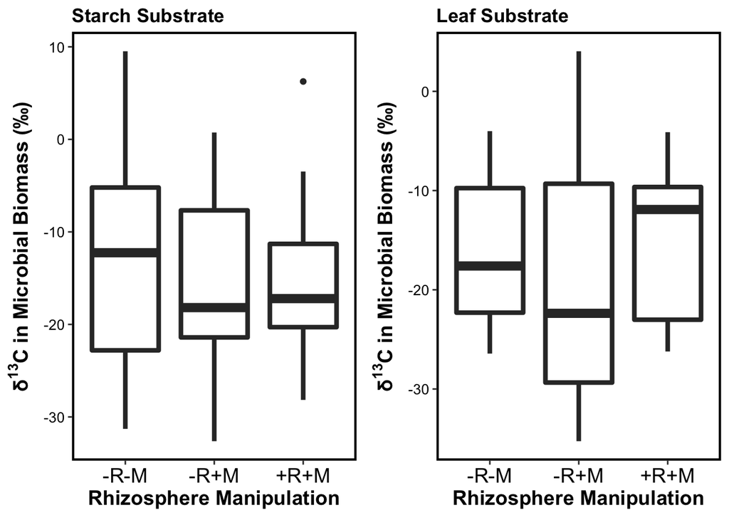

```r
#########################################################################################################
# FUNCTION: myBoxplots
# Produces boxplots from rhizosphere manipulation experiment.
# input: data = 4-column data frame (ID, rhizosphere manipulation treatment, substrate type, assimilation)
# output: Two-panelled figure containing boxplots for leaf and starch data.
#--------------------------------------------------------------------------------------------------------
library(dplyr)
library(gridExtra)
library(ggplot2)
myBoxplots<-function(data=NULL) {
  if (is.null(data)) {
    data<-data.frame(ID=seq(from=1,to=72),
                     Rhizosphere_Manipulation=rep(1:3,each=12,times=2),
                     Labeled_Substrate=rep(c("L","S"),each=36),
                     Assimilation_13C=rnorm(72,mean=-15,sd=10))
  }

  leafData<-filter(data,Labeled_Substrate=="L")
  starchData<-filter(data,Labeled_Substrate=="S")

  #### Starch Figure
  starchFig<-ggplot(starchData,aes(x=as.factor(Rhizosphere_Manipulation),y=Assimilation_13C)) +
    geom_boxplot(lwd=1.5) +
    labs(x=expression(bold("Rhizosphere Manipulation")),y=expression(bold(paste("\u03B4"^{bold("13")},"C in Microbial Biomass"," (\u2030)"))),title = expression(bold("Starch Substrate"))) +
    scale_x_discrete(labels=c("1"="-R-M","2"="-R+M","3"="+R+M")) +
      theme(panel.grid.minor=element_blank(),panel.grid.major=element_blank(),
        axis.text.y=element_text(colour="black",size=10),
        axis.text.x=element_text(colour="black",size=14),
        axis.title=element_text(size=14,face="bold"),
        panel.border=element_rect(fill=NA,colour="black",size=1.5),
        panel.background=element_rect(fill=NA))

  #### Leaf Figure
    leafFig<-ggplot(leafData,aes(x=as.factor(Rhizosphere_Manipulation),y=Assimilation_13C)) +
    geom_boxplot(lwd=1.5) +
    labs(x=expression(bold("Rhizosphere Manipulation")),y=expression(bold(paste("\u03B4"^{bold("13")},"C in Microbial Biomass"," (\u2030)"))),title = expression(bold("Leaf Substrate"))) +
    scale_x_discrete(labels=c("1"="-R-M","2"="-R+M","3"="+R+M")) +
      theme(panel.grid.minor=element_blank(),panel.grid.major=element_blank(),
        axis.text.y=element_text(colour="black",size=10),
        axis.text.x=element_text(colour="black",size=14),
        axis.title=element_text(size=14,face="bold"),
        panel.border=element_rect(fill=NA,colour="black",size=1.5),
        panel.background=element_rect(fill=NA))

    #### Final Paneled Figure
    grid.arrange(starchFig,leafFig,nrow=1)
}
#--------------------------------------------------------------------------------------------------------

myBoxplots() # Figures are successfully rendered using default data.
```

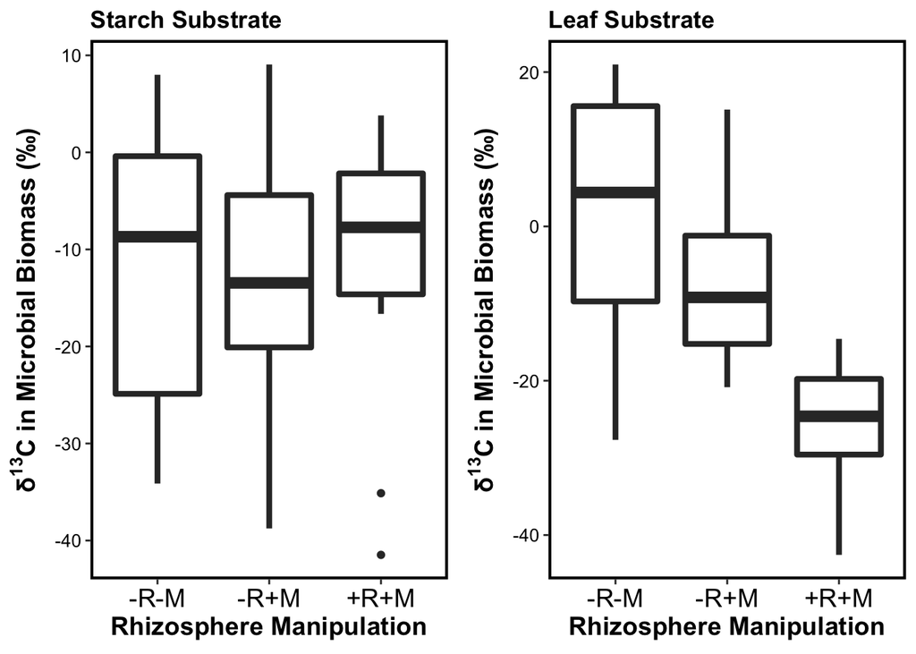

```r
myBoxplots(data=data) # Figures rendered successfully with simulated data.
```

Re-running the code that creates the data frame `data` for the simulated dataset and then running the `myANOVA` and `myBoxplots` functions will give you a feel for how different sets of random numbers within the same sampling parameters can generarte slightly different results.

#### Testing the experimental design to understand minimum effect size needed to retain significant results.

By adjusting the means of microbial substrate assimilation for rhizosphere manipulation group, we can investigate the minimume effect size needed to retain statistically signficant differences.

For the sake of simplicity, I will simulated and analyze the differences between only two rhizosphere manipulation groups, 1 (-R-M) and 3 (+R+M).

```r
#########################################################################################################
# FUNCTION: testEffect
# Varies group means, simulates 100 sets of data and runs an ANOVA on each dataset, returns dataframe of means used and resulting p-value.
# input:N = number of data simulations for each mean (default=50)
# output: two column data frame that shows difference between group means and the average p-value over all N iterations of data simulation and ANOVA for each mean
#--------------------------------------------------------------------------------------------------------

testEffect<-function(N=50) {
  K<-30
  mean_iterations<-c()
  mean_dif_vec<-c()
  p_Vec<-c()

  for (i in 1:K) {
  treat_mean<-(-25 + i) # Varies group 3 mean by incremental distances from background levels

    for (j in 1:N) {
    L1<-rnorm(12,mean=-25,sd=10) # Assume no assimilation, mean = ambient delta13 levels
    L3<-rnorm(12,mean=treat_mean,sd=10) # moderate assimilation
    L<-c(L1,L3) # All leaf data in one vector
    treat<-c(rep(1,times=12),rep(3,times=12))
    treat<-as.factor(treat)
    mod<-lm(L~treat)
    results<-anova(mod)
    mean_iterations[j]<-results$"Pr(>F)"[1]
    }

  p_Vec[i]<-mean(mean_iterations)
  mean_dif_vec[i]<-i
  }

  outDat<-data.frame(Mean_Difference=mean_dif_vec,p_value=p_Vec)
  return(outDat)
}

#--------------------------------------------------------------------------------------------------------
options(scipen = 999) # Forces results out of scientific notation for easier interpretation of p-values
testEffect()
```

```
##    Mean_Difference        p_value
## 1                1 0.436623257014
## 2                2 0.448642530205
## 3                3 0.424979867515
## 4                4 0.405910737121
## 5                5 0.328435931904
## 6                6 0.329334714324
## 7                7 0.229157360041
## 8                8 0.132902137665
## 9                9 0.126688390273
## 10              10 0.078289888038
## 11              11 0.092647919225
## 12              12 0.063555931837
## 13              13 0.012120852023
## 14              14 0.022790071469
```

[output cut: 16 more lines]